# R Notebook

# Lab Section

In this lab, we will go over regularization, classification and performance metrics. We will be using the caret package in R. https://topepo.github.io/caret/train-models-by-tag.html

# Perfomance Metrics

## K- fold cross validatation - Resampling method

Randomly split the training data into k folds. If you specify 10 folds, then you split the data into 10 partitions. Train the model on 9 of those partitions, and test your model on the 10th partition. Iterate through until every partition has been held out.

A smaller k is more biased, but a larger k can be very variable.

## Bootstrapping - Resampling method

Sample with replacement. Some samples may be represented several times within the boostrap sample, while others may not be represented at all. The samples that are not selected are called out of bag samples.

Boostrap error rates usually have less uncertainty than k-fold cross validation, but higher bias.

## Error

Deviation of the observed value to the true value (population mean)

## Residual

Deviation of the observed value to the estimated value (sample mean)
$$residual=y_i - \hat{y_i}$$
where $\hat{y_i}$ is the estimated value

## Mean Squared Error (MSE)

$$MSE=\frac{1}{n}\sum_{i=1}^{n}(y_i - \hat{y_i})^2$$

## Root Mean Squared Error (RMSE)

Same units as original data.

$$RMSE=\sqrt{MSE}$$

## R^2

Proportion of information explained by the model. It is a measure of correlation, not accuracy.
$$1-RSS/TSS$$

## L2 regularization : Ridge regression. Regularize by adding the sum of the coefficients, squared, to the function.

$$Ridge Regression=\sum_{i=1}^{n}(y_i - w_0 - \sum_{j=1}^{p}w_jx_{ij})^2 + \lambda\sum_{j=1}^p(w_j)^2$$

## L1 regularization : Lasso Regression. Regularize by adding the sum of the absolute value of the coefficients to the model. Coefficient estimates may be pushed to zero – Lasso can perform variable selection

$$Lasso Regression=\sum_{i=1}^{n}(y_i - w_0 - \sum_{j=1}^{p}w_jx_{ij})^2 + \lambda\sum_{j=1}^p|w_j|$$

## Sensitivity or True Positive Rate

TP = True Positives TN = True Negatives FP = False Positives - Type I error FN = False Negatives - Type II error N = actual negative samples P = actual positive samples

$$TPR=TP/(TP + FN)$$

## Specificity or True Negative Rate

$$TNR=TN/(TN + FP)$$

## Receiver Operating Characteristics (ROC)

Plot of True Positive Rate (sensitivity) against False Positive Rate, or plots the True Positive Rate (sensitivity) against specificity.

Either way, a good ROC curves up through the left corner, and has a large area underneath.

## Area under ROC curve (AUC)

The area underneath the ROC curve

## Logistic function:

$$P(X)=e^{w_0 + w_1X}/{1+e^{w_0+w_1X}}$$

### The broad steps of Machine learning in R.

1. Split the data into training and test. Set test aside.
2. Fit a good model to the training data. This includes using bootstapping, cross validation etc. to resample the training data and fit a good model.
3. Visualize if your model learned on the training data by looking at ROC curve and AUC.
4. Test how your model performs on the test data.

### Broad steps for choosing between models according to Max Kuhn and Kjell Johnson

1. Start with several models that are the least interpretable and the most flexible, like boosted trees and svms. These models are the often the most accurate.
2. Investigate simpler models that are less opaque, like partial least squares, generalized additive models, or naive bayes models.
3. Consider using the simplest model that reasonable approximates the performance of more complex models

```r
#install.packages("pROC")
#install.packages("glmnet")
#install.packages("elasticnet")
#install.packages("Amelia")
#install.packages('e1071', dependencies=TRUE)
#install.packages("car")
#install.packages("class")
#install.packages("pROC")
#install.packages("VIM")
```

Split data into training and test set

```r
train_size <- floor(0.75 * nrow(airquality))
set.seed(543)
train_pos <- sample(seq_len(nrow(airquality)), size = train_size)
train_regression <- airquality[train_pos,-c(1,2)]
test_regression <- airquality[-train_pos,-c(1,2)]

dim(train_regression)
```

```
## [1] 114   4
```

```r
dim(test_regression)
```

```
## [1] 39  4
```

## Resampling in R

```r
#?trainControl
```

## Ridge Regression

$$Ridge Regression=\sum_{i=1}^{n}(y_i - w_0 - \sum_{j=1}^{p}w_jx_{ij})^2 + \lambda\sum_{j=1}^p(w_j)^2$$
2. Create and train model

```r
ctrl =  trainControl(method = "boot", 15)

Ridge_regression <- train(Temp ~ Wind + Month, data = train_regression,
                          method = 'ridge', trControl= ctrl)
```

```r
Ridge_regression
```

```
## Ridge Regression
##
## 114 samples
##   2 predictor
##
## No pre-processing
## Resampling: Bootstrapped (15 reps)
## Summary of sample sizes: 114, 114, 114, 114, 114, 114, ...
## Resampling results across tuning parameters:
##
##   lambda  RMSE      Rsquared   MAE
##   0e+00   7.818663  0.3732997  6.249745
##   1e-04   7.818659  0.3733006  6.249736
##   1e-01   7.815678  0.3740900  6.242047
##
## RMSE was used to select the optimal model using the smallest value.
## The final value used for the model was lambda = 0.1.
```

Examine the residuals

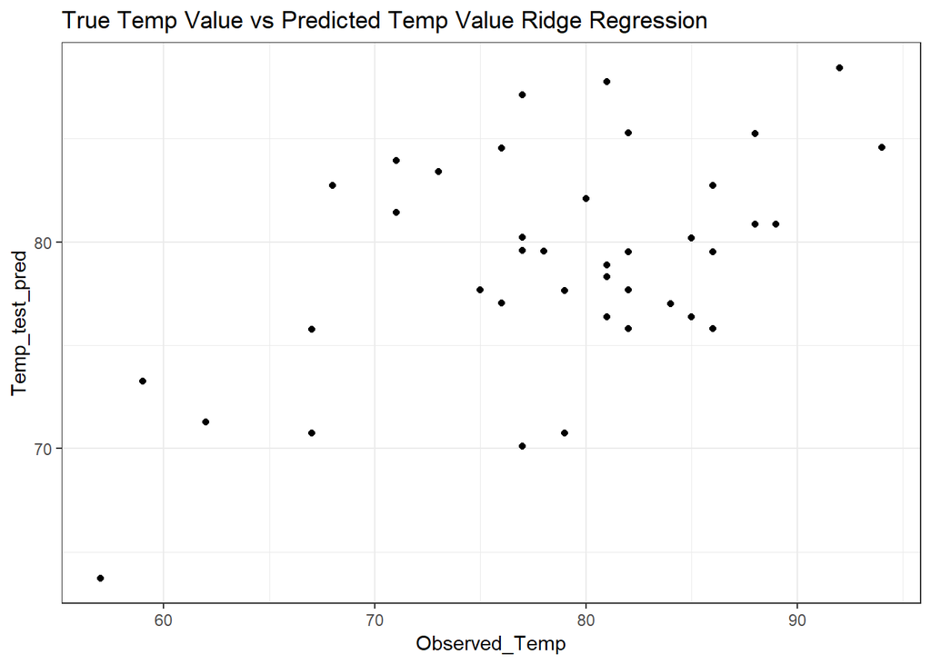

```r
ridge_test_pred <- predict(Ridge_regression, newdata = test_regression)

#plot the predicted values vs the observed values
plot_ridge_test_pred <- data.frame(Temp_test_pred = ridge_test_pred,
                                   Observed_Temp = test_regression$Temp)
ggplot(data = plot_ridge_test_pred) +
  geom_point(aes(x=Observed_Temp, y = Temp_test_pred)) +
  ggtitle("True Temp Value vs Predicted Temp Value Ridge Regression") +
  theme_bw()
```

```r
#median residual value should be close to zero
median(resid(Ridge_regression)) # -0.09496351
```

```
## [1] -0.09496351
```

# Homework

## Lasso

$$Lasso Regression=\sum_{i=1}^{n}(y_i - w_0 - \sum_{j=1}^{p}w_jx_{ij})^2 + \lambda\sum_{j=1}^p|w_j|$$
2. Create and train model

```r
ctrl =  trainControl(method = "boot", 15)

Lasso_regression <- train(Temp ~ Wind + Month, data = train_regression,
                          method = 'lasso', trControl= ctrl)
```

Examine the residuals

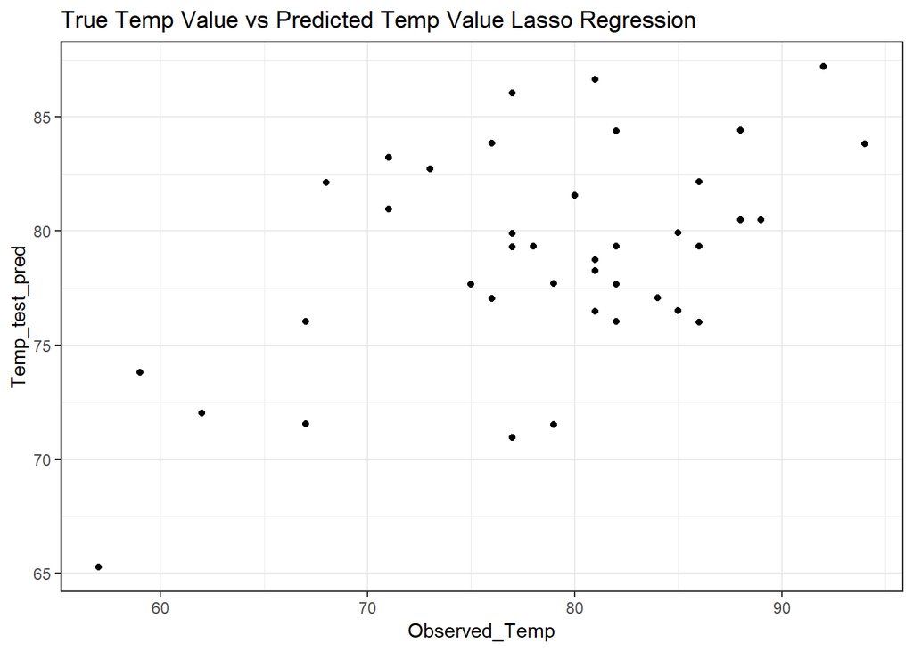

```r
lasso_test_pred <- predict(Lasso_regression, newdata = test_regression)

#plot the predicted values vs the observed values
plot_lasso_test_pred <- data.frame(Temp_test_pred = lasso_test_pred,
                                   Observed_Temp = test_regression$Temp)
ggplot(data = plot_lasso_test_pred) +
  geom_point(aes(x=Observed_Temp, y = Temp_test_pred)) +
  ggtitle("True Temp Value vs Predicted Temp Value Lasso Regression") +
  theme_bw()
```

```r
#median residual value should be close to zero
median(resid(Lasso_regression)) # 0.1387928
```

```
## [1] 0.1387928
```

# Classification

1. Split into training and test set

```r
data(iris)

#split into training and test set
train_size <- floor(0.75 * nrow(iris))
set.seed(543)
train_pos <- sample(seq_len(nrow(iris)), size = train_size)
train_classifier <- iris[train_pos,]
test_classifier <- iris[-train_pos,]

dim(train_classifier)
```

```
## [1] 112   5
```

```r
dim(test_classifier)
```

```
## [1] 38  5
```

## Linear Discriminant analysis

- Good for well separated classes, more stable with small n than logistic regression, and good for more than 2 response classes.
- LDA assumes a normal distribution with a class specific mean and common variance.

Let’s see if our data follows the assumptions of LDA.

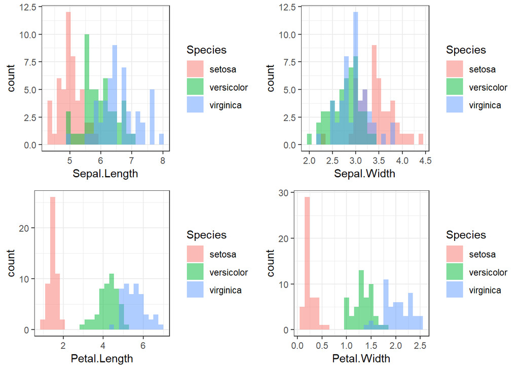

```r
slength <- ggplot(data = iris, aes(x = Sepal.Length, fill = Species)) +
  geom_histogram(position="identity", alpha=0.5, bins= 25)  +
  theme_bw()
swidth <- ggplot(data = iris, aes(x = Sepal.Width, fill = Species)) +
  geom_histogram(position="identity", alpha=0.5, bins= 25) +
  theme_bw()
plength <- ggplot(data = iris, aes(x = Petal.Length, fill = Species)) +
  geom_histogram(position="identity", alpha=0.5, bins= 25) +
  theme_bw()
pwidth <- ggplot(data = iris, aes(x = Petal.Width, fill = Species)) +
  geom_histogram(position="identity", alpha=0.5, bins= 25) +
  theme_bw()

grid.arrange(slength, swidth, plength, pwidth)
```

```r
LDA <- lda(Species~ Sepal.Length + Sepal.Width + Petal.Length + Petal.Width,
           data= train_classifier, cv= T)
```

```r
LDA
```

```
## Call:
## lda(Species ~ Sepal.Length + Sepal.Width + Petal.Length + Petal.Width,
##     data = train_classifier, cv = T)
##
## Prior probabilities of groups:
##     setosa versicolor  virginica
##  0.3303571  0.3303571  0.3392857
##
## Group means:
##            Sepal.Length Sepal.Width Petal.Length Petal.Width
## setosa         4.991892    3.427027     1.467568   0.2513514
## versicolor     5.929730    2.775676     4.316216   1.3486486
## virginica      6.631579    2.963158     5.584211   1.9921053
##
## Coefficients of linear discriminants:
##                    LD1        LD2
## Sepal.Length  1.053740 -0.3504079
## Sepal.Width   1.164761 -1.9499297
## Petal.Length -2.338670  1.0990348
## Petal.Width  -2.729158 -2.9432294
##
## Proportion of trace:
##    LD1    LD2
## 0.9928 0.0072
```

4. Test model on test set

```r
#predict the species of the test data
LDA_predict <- predict(LDA, newdata=test_classifier)
confusionMatrix(LDA_predict$class, reference = test_classifier$Species)
```

```
## Confusion Matrix and Statistics
##
##             Reference
## Prediction   setosa versicolor virginica
##   setosa         13          0         0
##   versicolor      0         13         1
##   virginica       0          0        11
##
## Overall Statistics
##
##                Accuracy : 0.9737
##                  95% CI : (0.8619, 0.9993)
##     No Information Rate : 0.3421
##     P-Value [Acc > NIR] : < 2.2e-16
##
##                   Kappa : 0.9605
##
##  Mcnemar's Test P-Value : NA
##
## Statistics by Class:
##
##                      Class: setosa Class: versicolor Class: virginica
## Sensitivity                 1.0000            1.0000           0.9167
## Specificity                 1.0000            0.9600           1.0000
## Pos Pred Value              1.0000            0.9286           1.0000
## Neg Pred Value              1.0000            1.0000           0.9630
## Prevalence                  0.3421            0.3421           0.3158
## Detection Rate              0.3421            0.3421           0.2895
## Detection Prevalence        0.3421            0.3684           0.2895
## Balanced Accuracy           1.0000            0.9800           0.9583
```

```r
# save the predictions in a new variable
predictions <- as.data.frame(LDA_predict$posterior) %>%
  rownames_to_column("idx")

test_classifier <- test_classifier %>%
  rownames_to_column("idx")

predictions_actual <- full_join(predictions,test_classifier, by = "idx" )

# choose the two classes we want to compare, setosa and versicolor
set_vers_true_labels <- predictions_actual %>%
  filter(Species %in% c("setosa", "versicolor")) %>%
  mutate(Species = as.character(Species))

#make dataframe of the prediction and the label
pred_label <- data.frame(prediction = set_vers_true_labels$setosa,
                         label = set_vers_true_labels$Species)

ggplot(pred_label, aes(x = 1:24, y = prediction, color = label))+
  geom_point()

pred <- prediction(set_vers_true_labels$setosa, set_vers_true_labels$Species,
label.ordering = c("versicolor", "setosa"))

perf <- performance(pred,"tpr","fpr")
plot(perf)
```

[output not shown]

## Logistic Regression

$logodds_i=B_0 + B_1X_{i1}$

Here, the log odds represents the log odds of $Y_i$ being 0 or 1.

Where $logodds$ is the dependent variable, and $X_i$ is the independent variable. $B_{number}$ are the parameters to fit.

Logistic Regression assumes a linear relationship between the $logodds$ and $X$.

To convert from logodds, a not intuitive quantity, to odds, a more intuitive quantity, we use this non-linear equation:

$odds_i=e^{logodds_{i}}$ or $odds_i=e^{B_0 + B_1X_{i1}}$

Odds is defined as the probability that the event will occur divided by the probability that the event will not occur.

Now we convert from odds to probability.

The probability that an event will occur is the fraction of times you expect to see that event in many trials. Probabilities always range between 0 and 1.

To convert from odds to a probability, divide the odds by one plus the odds. So to convert odds of 1/9 to a probability, divide 1/9 by 10/9 to obtain the probability of 0.10

$P=odds/(odds+1)$

## Logistic Regression implementation

- Y=1 is the probability of the event occuring.
- Independent variables should not be correlated.
- Log odds and independent variables should be linearly correlated.
2. Train and fit model

```r
data(iris)

#split into training and test set
train_size <- floor(0.75 * nrow(iris))
set.seed(543)
train_pos <- sample(seq_len(nrow(iris)), size = train_size)
train_classifier <- iris[train_pos,]
test_classifier <- iris[-train_pos,]


dim(train_classifier)
```

```
## [1] 112   5
```

```r
dim(test_classifier)
```

```
## [1] 38  5
```

```r
#only look at two classes
train_classifier_log <- train_classifier[c(which(train_classifier$Species == "setosa"),
                                           which(train_classifier$Species == "versicolor")),]
test_classifier_log <- test_classifier[c(which(test_classifier$Species == "setosa"),
                                         which(test_classifier$Species == "versicolor")),]

train_classifier_log$Species <- factor(train_classifier_log$Species)
test_classifier_log$Species <- factor(test_classifier_log$Species)

ctrl <- trainControl(method = "repeatedcv", repeats = 15,classProbs = T,
                     savePredictions = T)

#create model. logistic regression is a bionomial general linear model.
#predict species based on sepal length
logistic_regression <- train(Species~ Sepal.Length, data = train_classifier_log,
                             method = "glm", family= "binomial", trControl = ctrl)
```

```r
logistic_regression
```

```
## Generalized Linear Model
##
## 74 samples
##  1 predictor
##  2 classes: 'setosa', 'versicolor'
##
## No pre-processing
## Resampling: Cross-Validated (10 fold, repeated 15 times)
## Summary of sample sizes: 67, 67, 67, 67, 66, 66, ...
## Resampling results:
##
##   Accuracy   Kappa
##   0.8751984  0.7483604
```

```r
summary(logistic_regression)
```

```
##
## Call:
## NULL
##
## Deviance Residuals:
##      Min        1Q    Median        3Q       Max
## -1.98465  -0.43322  -0.02248   0.40932   2.14846
##
## Coefficients:
##              Estimate Std. Error z value Pr(>|z|)
## (Intercept)   -27.343      6.362  -4.298 1.73e-05 ***
## Sepal.Length    5.028      1.168   4.305 1.67e-05 ***
## ---
## Signif. codes:  0 '***' 0.001 '**' 0.01 '*' 0.05 '.' 0.1 ' ' 1
##
## (Dispersion parameter for binomial family taken to be 1)
##
##     Null deviance: 102.586  on 73  degrees of freedom
## Residual deviance:  47.527  on 72  degrees of freedom
## AIC: 51.527
##
## Number of Fisher Scoring iterations: 6
```

3. Visualize ROC curve

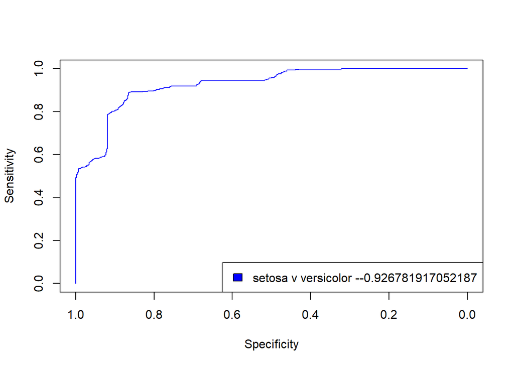

```r
plot(x = roc(predictor = logistic_regression$pred$setosa,
             response = logistic_regression$pred$obs)$specificities,
     y = roc(predictor = logistic_regression$pred$setosa,
             response = logistic_regression$pred$obs)$sensitivities,
     col= "blue", xlim = c(1, 0), type ="l", ylab = "Sensitivity",
     xlab = "Specificity")
legend("bottomright", legend = paste("setosa v versicolor --",
                                     roc(predictor = logistic_regression$pred$setosa,
                                         response = logistic_regression$pred$obs)$auc
, sep = ""), col = c("blue"), fill = c("blue"))
```

4. Test on an independent set

```r
#predict iris species using Sepal legth
logistic_regression_predict_class <- predict(logistic_regression,
                                             newdata = test_classifier_log)

#confusion matrix
confusionMatrix(logistic_regression_predict_class,
                reference = test_classifier_log$Species)
```

```
## Confusion Matrix and Statistics
##
##             Reference
## Prediction   setosa versicolor
##   setosa         13          2
##   versicolor      0         11
##
##                Accuracy : 0.9231
##                  95% CI : (0.7487, 0.9905)
##     No Information Rate : 0.5
##     P-Value [Acc > NIR] : 5.245e-06
##
##                   Kappa : 0.8462
##
##  Mcnemar's Test P-Value : 0.4795
##
##             Sensitivity : 1.0000
##             Specificity : 0.8462
##          Pos Pred Value : 0.8667
##          Neg Pred Value : 1.0000
##              Prevalence : 0.5000
##          Detection Rate : 0.5000
##    Detection Prevalence : 0.5769
##       Balanced Accuracy : 0.9231
##
##        'Positive' Class : setosa
##
```

Check if log odds and independent variables are linearly correlated

```r
logistic_regression_predict <- predict(logistic_regression,
                                       newdata = test_classifier_log, type = "prob")

# To convert from a probability to odds, divide the probability by one minus that probability. So if the probability is 10% or 0.10 , then the odds are 0.1/0.9 or ‘1 to 9’

odds_species1 <- logistic_regression_predict[,1] / (1 - logistic_regression_predict[,1])
log_odds_species1 <- log(odds_species1)
cor.test(log_odds_species1, test_classifier_log$Sepal.Length)
```

```
##
##  Pearson's product-moment correlation
##
## data:  log_odds_species1 and test_classifier_log$Sepal.Length
## t = -Inf, df = 24, p-value < 2.2e-16
## alternative hypothesis: true correlation is not equal to 0
## 95 percent confidence interval:
##  -1 -1
## sample estimates:
## cor
##  -1
```

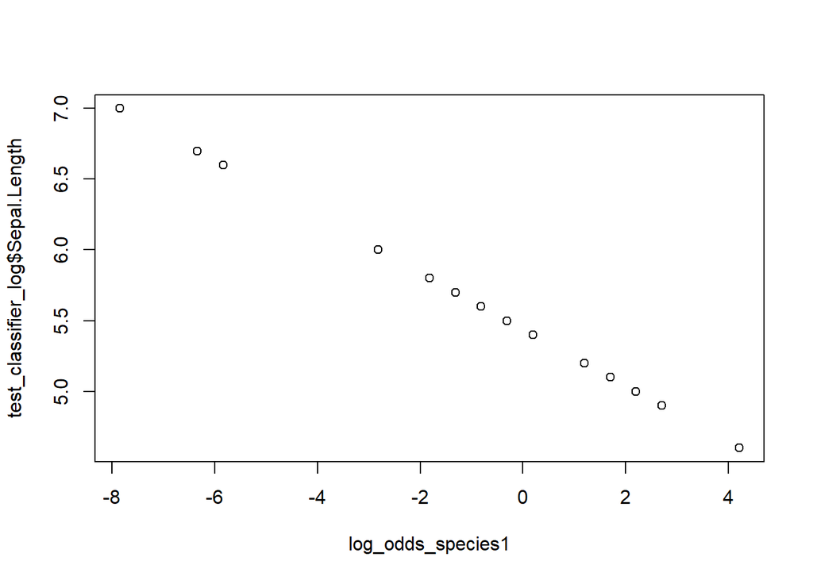

```r
plot(log_odds_species1, test_classifier_log$Sepal.Length)
```

Look deeper at the logistic regression

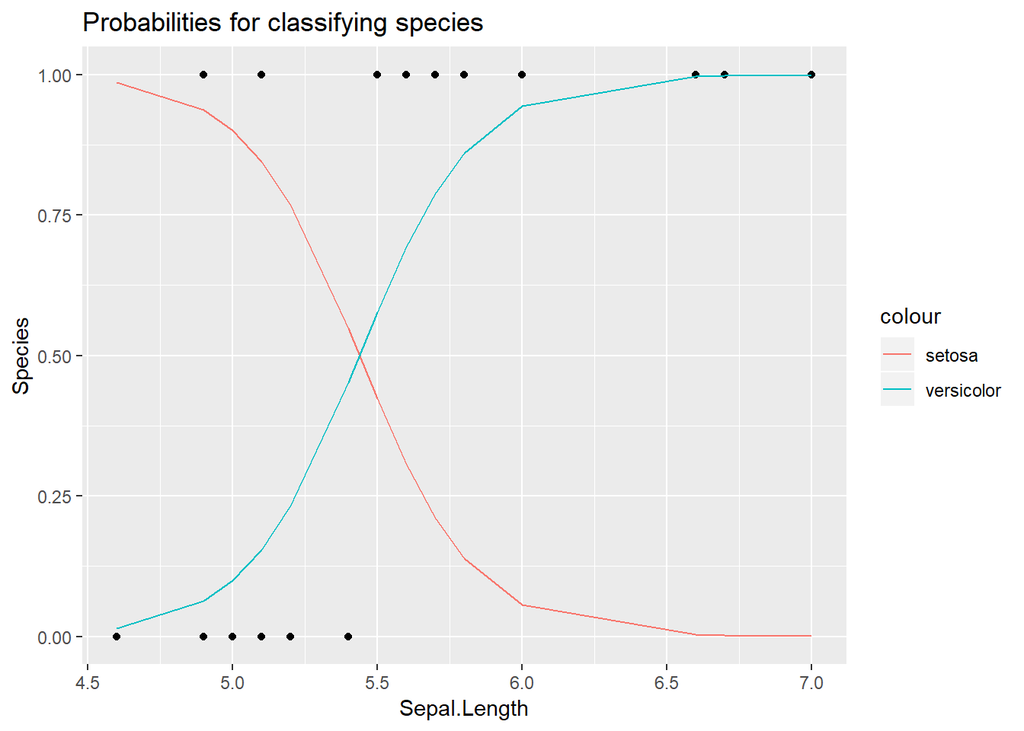

```r
logistic_predict_prob <- predict(logistic_regression,
                                 newdata = test_classifier_log, type="prob")

logistic_pred_prob_plot <- data.frame(Species_pred = logistic_predict_prob, Sepal.Length  = test_classifier_log$Sepal.Length)

test_classifier_log$Species <- as.numeric(test_classifier_log$Species) -1

ggplot(data = test_classifier_log) +
  geom_point(aes(x=Sepal.Length, y = Species)) +
  geom_line(data = logistic_pred_prob_plot, aes(x = Sepal.Length,
                                                y = Species_pred.setosa, col =  "setosa"))+
  geom_line(data = logistic_pred_prob_plot, aes(x = Sepal.Length,
                                                y = Species_pred.versicolor, col = "versicolor"))+
  ggtitle("Probabilities for classifying species")
```

# Homework:

1. Use the Breast Cancer dataset from the mlbench package, and predict whether the cancer is malignant or benign using one of the algorithms we learned about in class. Give some rationale as to why you chose this algorithm. Plot ROC curves, and confusion matrices. If you are choosing a hyperparameter like K or lambda, explain how and why you chose it.

```r
library(mlbench)
data(BreastCancer)

# The KNN approach will be used for classification, preferred over other methods because it is highly unbiased in nature and makes no prior assumptions of the underlying data. However, its major disadvantage is that it will not reduce the number of parameters to estimate, like parametric models do. Therefore, a large number of observations are required for an accurate estimation of the functional form of f. Fortunately in this case, the data set appears to be sufficiently large enough for a non-parametric approach.

# DATA WRANGLING

# view structure
str(BreastCancer)
```

```
## 'data.frame':    699 obs. of  11 variables:
##  $ Id             : chr  "1000025" "1002945" "1015425" "1016277" ...
##  $ Cl.thickness   : Ord.factor w/ 10 levels "1"<"2"<"3"<"4"<..: 5 5 3 6 4 8 1 2 2 4 ...
##  $ Cell.size      : Ord.factor w/ 10 levels "1"<"2"<"3"<"4"<..: 1 4 1 8 1 10 1 1 1 2 ...
##  $ Cell.shape     : Ord.factor w/ 10 levels "1"<"2"<"3"<"4"<..: 1 4 1 8 1 10 1 2 1 1 ...
##  $ Marg.adhesion  : Ord.factor w/ 10 levels "1"<"2"<"3"<"4"<..: 1 5 1 1 3 8 1 1 1 1 ...
##  $ Epith.c.size   : Ord.factor w/ 10 levels "1"<"2"<"3"<"4"<..: 2 7 2 3 2 7 2 2 2 2 ...
##  $ Bare.nuclei    : Factor w/ 10 levels "1","2","3","4",..: 1 10 2 4 1 10 10 1 1 1 ...
##  $ Bl.cromatin    : Factor w/ 10 levels "1","2","3","4",..: 3 3 3 3 3 9 3 3 1 2 ...
##  $ Normal.nucleoli: Factor w/ 10 levels "1","2","3","4",..: 1 2 1 7 1 7 1 1 1 1 ...
##  $ Mitoses        : Factor w/ 9 levels "1","2","3","4",..: 1 1 1 1 1 1 1 1 5 1 ...
##  $ Class          : Factor w/ 2 levels "benign","malignant": 1 1 1 1 1 2 1 1 1 1 ...
```

```r
# Missing value management

sum(is.na(BreastCancer)) # 16 missing values present
```

```
## [1] 16
```

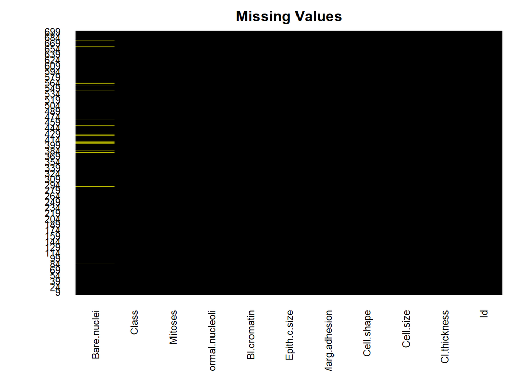

```r
# visually identify which attribute(s) contains the missing values

missmap(BreastCancer, main = 'Missing Values', col = c('yellow', 'black'), legend = FALSE)
```

```r
# map shows missing values all belong to one attribute: Bare.nuclei

# na.exclude function removes missing values but, unlike na.omit, may preserve the integrity of the analysis.

# NOTE: The k nearest neighbors algorithm can be used for imputing missing data. The means of the closest neighbors to the missing data are used for imputation. However, this approach was tried and resulted in a higher test error rate. Therefore, the na.exclude function is preferred.

# apply na.exclude function
BreastCancer <- na.exclude(BreastCancer)

# re-check number of missing values
sum(is.na(BreastCancer)) # nil na values
```

```
## [1] 0
```

```r
# Ordering will impact on the integrity of the analysis, therefore it is removed from ordinal factors
BreastCancer$Cl.thickness <- factor(BreastCancer$Cl.thickness, ordered = FALSE)
BreastCancer$Cell.size <- factor(BreastCancer$Cell.size, ordered = FALSE)
BreastCancer$Cell.shape <- factor(BreastCancer$Cell.shape, ordered = FALSE)
BreastCancer$Marg.adhesion <- factor(BreastCancer$Marg.adhesion, ordered = FALSE)
BreastCancer$Epith.c.size <- factor(BreastCancer$Epith.c.size, ordered = FALSE)

# remove Id variable as not required for analysis
BreastCancer <- select(BreastCancer, -Id)

# check removal
str(BreastCancer)
```

```
## 'data.frame':    683 obs. of  10 variables:
##  $ Cl.thickness   : Factor w/ 10 levels "1","2","3","4",..: 5 5 3 6 4 8 1 2 2 4 ...
##  $ Cell.size      : Factor w/ 10 levels "1","2","3","4",..: 1 4 1 8 1 10 1 1 1 2 ...
##  $ Cell.shape     : Factor w/ 10 levels "1","2","3","4",..: 1 4 1 8 1 10 1 2 1 1 ...
##  $ Marg.adhesion  : Factor w/ 10 levels "1","2","3","4",..: 1 5 1 1 3 8 1 1 1 1 ...
##  $ Epith.c.size   : Factor w/ 10 levels "1","2","3","4",..: 2 7 2 3 2 7 2 2 2 2 ...
##  $ Bare.nuclei    : Factor w/ 10 levels "1","2","3","4",..: 1 10 2 4 1 10 10 1 1 1 ...
##  $ Bl.cromatin    : Factor w/ 10 levels "1","2","3","4",..: 3 3 3 3 3 9 3 3 1 2 ...
##  $ Normal.nucleoli: Factor w/ 10 levels "1","2","3","4",..: 1 2 1 7 1 7 1 1 1 1 ...
##  $ Mitoses        : Factor w/ 9 levels "1","2","3","4",..: 1 1 1 1 1 1 1 1 5 1 ...
##  $ Class          : Factor w/ 2 levels "benign","malignant": 1 1 1 1 1 2 1 1 1 1 ...
##  - attr(*, "na.action")= 'exclude' Named int  24 41 140 146 159 165 236 250 276 293 ...
##   ..- attr(*, "names")= chr  "24" "41" "140" "146" ...
```

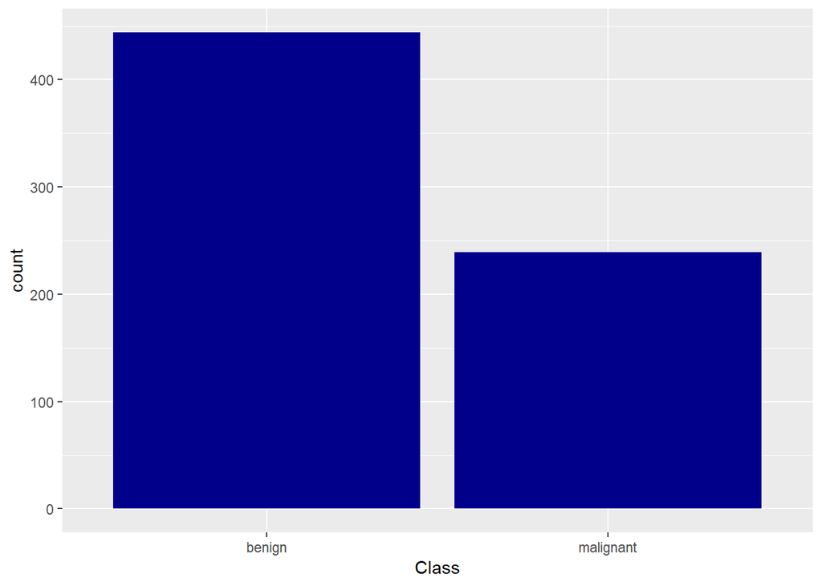

```r
# visually explore data
ggplot(BreastCancer, aes(Class)) + geom_bar(fill = 'darkblue')
```

```r
# shows number of benign cancers are substantially more than malignant cancers

# obtain precise figures for benign and malignant cancers
table(BreastCancer$Class)
```

```
##
##    benign malignant
##       444       239
```

```r
#  benign malignant
#     444       239

# obtain percentages for benign and malignant cancers
round(prop.table(table(BreastCancer$Class)) * 100, digits = 1)
```

```
##
##    benign malignant
##        65        35
```

```r
# benign malignant
#     65        35
```

```r
# TRAIN AND FIT MODEL

# re-label classification variable (variable that lists numbers of benign and malignant cancers)
Cancer_class <- BreastCancer[,10]

# classification variable requires removal from main data set when using KNN (and will be split into training and test sets separately)
BreastCancer_attributes <- BreastCancer[,-10]

# split into training and test sets

train_size <- floor(0.75 * nrow(BreastCancer_attributes))
set.seed(543)
train_pos <- sample(seq_len(nrow(BreastCancer_attributes)), size = train_size)
train_classifier <- BreastCancer_attributes[train_pos,]
Cancer_class.train <- Cancer_class[train_pos]
test_classifier <- BreastCancer_attributes[-train_pos,]
Cancer_class.test <- Cancer_class[-train_pos]

# check dimensions of sets
dim(train_classifier)
```

```
## [1] 512   9
```

```r
dim(test_classifier)
```

```
## [1] 171   9
```

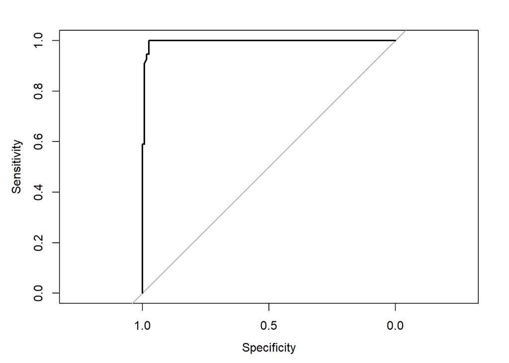

```
##
## Call:
## roc.default(response = Cancer_class.test, predictor = x, plot = TRUE)
##
## Data: x in 115 controls (Cancer_class.test benign) < 56 cases (Cancer_class.test malignant).
## Area under the curve: 0.9953
```

```r
# K VALUE SELECTION

# The k value is selected using the convention of taking the square root of the total number of observations ie square root of 683 is 26.13, rounded to 26. Note: if the original observation figure of 699 (that included the null values) is used, the rounded square root is still 26.

# MODEL

Predicted.Cancer_class <- knn(train = train_classifier, test = test_classifier,cl = Cancer_class.train, k=26, prob = TRUE)

# EVALUATION Of PERFORMANCE

# ROC plot

x = attr(Predicted.Cancer_class,"prob")
x[Predicted.Cancer_class == 'benign'] = 1-x[Predicted.Cancer_class == 'benign']
roc(Cancer_class.test, x, plot = TRUE)
```

```r
# area under the curve: 0.9953
# Shape of plot looks favourable: it would appear KNN is an appropriate classification method for this data set.

# test error rate

mean(Cancer_class.test != Predicted.Cancer_class)
```

```
## [1] 0.01754386
```

```r
# 0.01754386 -> appears to be a v.good result

# confusion matrix

confusionMatrix(Predicted.Cancer_class,
                reference = Cancer_class.test)
```

```
## Confusion Matrix and Statistics
##
##            Reference
## Prediction  benign malignant
##   benign       112         0
##   malignant      3        56
##
##                Accuracy : 0.9825
##                  95% CI : (0.9496, 0.9964)
##     No Information Rate : 0.6725
##     P-Value [Acc > NIR] : <2e-16
##
##                   Kappa : 0.9607
##
##  Mcnemar's Test P-Value : 0.2482
##
##             Sensitivity : 0.9739
##             Specificity : 1.0000
##          Pos Pred Value : 1.0000
##          Neg Pred Value : 0.9492
##              Prevalence : 0.6725
##          Detection Rate : 0.6550
##    Detection Prevalence : 0.6550
##       Balanced Accuracy : 0.9870
##
##        'Positive' Class : benign
##
```

```r
# 56 out of 56 MALIGNANT cancers were correctly identified, and only 3 of the 115 BENIGN cancers were incorrectly identified. Conclusion: this would appear to be a very good model. For this model, false negatives are better than false positives ie it is better to predict a benign cancer as malignant than to predict a malignant cancer as benign. Essentially, the model should not miss detecting a malignant cancer.

# CAN THE MODEL BE IMPROVED?

# The model may be improved by using a different k value. This can be explored by changing the k value, and then calculating the error rate to see if it decreases with the new k value. An efficient way to do this is with a loop: a range of k values can be tested in this manner.    k values ranging from 1 to 40 will be tested.

# k value loop

Predicted.Cancer_class = NULL
error.rate = NULL

for(i in 1:40){
    set.seed(101)
    Predicted.Cancer_class = knn(train_classifier,test_classifier,Cancer_class.train,k=i)
    error.rate[i] = mean(Cancer_class.test != Predicted.Cancer_class)
}
error.rate # Demonstrates that the lowest error rate is 0.01754386, which is the error rate associated with the k value of 26 that was used. Note that this same error rate is associated with the range of k values between 20 to 34.
```

```
##  [1] 0.02923977 0.03508772 0.02923977 0.02923977 0.03508772 0.03508772
##  [7] 0.03508772 0.02923977 0.03508772 0.03508772 0.02923977 0.02923977
## [13] 0.02923977 0.02339181 0.02339181 0.02339181 0.02339181 0.02339181
## [19] 0.02339181 0.01754386 0.01754386 0.01754386 0.01754386 0.01754386
## [25] 0.01754386 0.01754386 0.01754386 0.01754386 0.01754386 0.01754386
## [31] 0.01754386 0.01754386 0.01754386 0.01754386 0.02923977 0.02923977
## [37] 0.02923977 0.02923977 0.02923977 0.02923977
```

```r
# Correct selection of the k value can be visually confirmed by the ELBOW method, by plotting the various error rates for the range of k values.

k.values <- 1:40

error.dataframe <- data.frame(error.rate, k.values)

error.dataframe
```

| error.rate | k.values |
| --- | --- |
| 0.02923977 | 1 |
| 0.03508772 | 2 |
| 0.02923977 | 3 |
| 0.02923977 | 4 |
| 0.03508772 | 5 |
| 0.03508772 | 6 |
| 0.03508772 | 7 |
| 0.02923977 | 8 |
| 0.03508772 | 9 |
| 0.03508772 | 10 |

[output cut: 30 more lines]

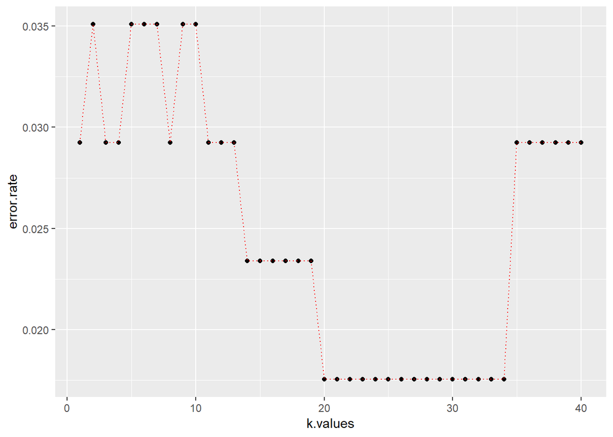

```r
ggplot(error.dataframe, aes(x = k.values, y = error.rate)) + geom_point() +        geom_line(lty = "dotted", color = 'red')
```

```r
# The plot confirms that the k value of 26 that was selected is associated with the lowest error rate. Therefore, the optimal k value has been chosen, and the performance of the model has been optimised in that respect.
```

References: https://sebastianraschka.com/Articles/2014_python_lda.html

https://towardsdatascience.com/building-a-multiple-linear-regression-model-and-assumptions-of-linear-regression-a-z-9769a6a0de42

http://www.statisticssolutions.com/wp-content/uploads/wp-post-to-pdf-enhanced-cache/1/assumptions-of-logistic-regression.pdf

https://machinelearningmastery.com/linear-discriminant-analysis-for-machine-learning/ , https://sebastianraschka.com/Articles/2014_python_lda.html

Other cool sites: https://www.countbayesie.com/blog/2019/6/12/logistic-regression-from-bayes-theorem https://colah.github.io/posts/2014-03-NN-Manifolds-Topology/